# Team 1 - Lab 2

MARSS models

Mary Orrand, Nicole Doran, Tina

April 22, 2025

# 1 Data

In this lab, we use multivariate autoregressive state-space (MARSS) models to estimate spawner abundance over time for the Oregon Coast Coho ESU. The goals of the lab are to estimate missing values, evaluate trends in abundance, and explore whether grouping populations improves model fit. Team 1 will be working with the Eastern Or coho salmon data, “1. Salmon, coho (Oregon Coast ESU) `esu[7]`”.

Question 1: Create estimates of spawner abundance for all missing years and provide estimates of the decline from the historical abundance.

Load the data.

```r
load(here::here("Lab-2", "Data_Images", "esa-salmon.rda"))
```

Wrangle the data.

We begin by sub-setting the Oregon Coast Coho ESU from the full salmon data set.

```r
## Packages
library(MARSS)
```

```r
library(ggplot2)
library(dplyr)
library(forecast)
library(tidyverse)
library(zoo)
library(corrplot)
### Data exploration
esu <- unique(esa.salmon$esu_dps)
esunum <- which(esu == esu[7])
esuname <- esu[esunum]
```

```r
## ---- new-plotesu -----------------------------------------------------------
plotesu <- function(esuname, keep_set = NULL) {
  df <- esa.salmon %>%
    filter(esu_dps %in% esuname) %>%
    { if (!is.null(keep_set)) filter(., esapopname %in% keep_set) else . }

  ggplot(df, aes(x = spawningyear,
                 y = log(value),
                 colour = majorpopgroup)) +
    geom_point(size = 0.2, na.rm = TRUE) +
    facet_wrap(~esapopname) +
    theme(strip.text.x = element_text(size = 3),
          axis.text.x  = element_text(size = 5, angle = 90)) +
    ggtitle(paste0(esuname, collapse = "\n"))
}
```

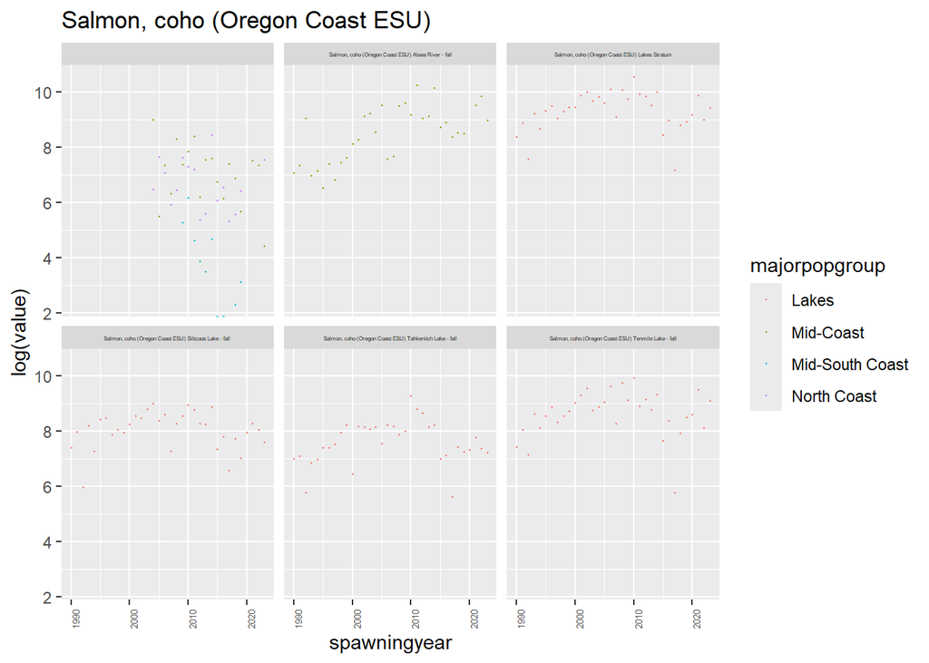

```r
## ---- pick-a-handful --------------------------------------------------------
keep <- head(unique(esa.salmon$esapopname[esa.salmon$esu_dps == esu[7]]), 6)

## ---- plot-the-handful ------------------------------------------------------
plotesu(esu[7], keep)
```

```r
## Create data frames for our ESU
esa_filtered <- esa.salmon %>%
  filter(esu_dps == esuname, esapopname != "") %>%
  mutate(log.spawner = log(value)) %>%
  mutate(log.spawner = replace(log.spawner, is.infinite(log.spawner), NA))
```

```r
#Lookup data frame for major pop groups
pop.groups <- esa_filtered %>%
  select(esapopname, majorpopgroup) %>%
  distinct()%>%
  as.matrix()
```

```r
# Time series matrix for MARSS
coho<- esa_filtered %>%
  select(esapopname, spawningyear, log.spawner) %>%
  pivot_wider(
    names_from = "esapopname",
    values_from = "log.spawner",
    values_fn = mean
  ) %>%
  column_to_rownames(var = "spawningyear") %>%
  as.matrix() %>%
  t()
coho[is.na(coho)] <- NA
head(coho)
```

```
##                                                            1990     1991
## Salmon, coho (Oregon Coast ESU) Lakes Stratum          8.387995 8.888895
## Salmon, coho (Oregon Coast ESU) Siltcoos Lake - fall   7.391415 7.970740
## Salmon, coho (Oregon Coast ESU) Tahkenitch Lake - fall 6.989335 7.102499
## Salmon, coho (Oregon Coast ESU) Tenmile Lake - fall    7.430707 8.052296
## Salmon, coho (Oregon Coast ESU) Alsea River - fall     7.087574 7.353082
## Salmon, coho (Oregon Coast ESU) Beaver Creek - fall    4.499810 6.182085
##                                                            1992     1993
## Salmon, coho (Oregon Coast ESU) Lakes Stratum          7.593878 9.224736
## Salmon, coho (Oregon Coast ESU) Siltcoos Lake - fall   5.968708 8.194782
## Salmon, coho (Oregon Coast ESU) Tahkenitch Lake - fall 5.762051 6.860664
## Salmon, coho (Oregon Coast ESU) Tenmile Lake - fall    7.152269 8.624971
## Salmon, coho (Oregon Coast ESU) Alsea River - fall     9.046291 6.976348
## Salmon, coho (Oregon Coast ESU) Beaver Creek - fall    6.426488 5.616771
##                                                            1994     1995
## Salmon, coho (Oregon Coast ESU) Lakes Stratum          8.672828 9.325097
## Salmon, coho (Oregon Coast ESU) Siltcoos Lake - fall   7.262629 8.411166
## Salmon, coho (Oregon Coast ESU) Tahkenitch Lake - fall 6.967909 7.394493
## Salmon, coho (Oregon Coast ESU) Tenmile Lake - fall    8.117909 8.535426
## Salmon, coho (Oregon Coast ESU) Alsea River - fall     7.153834 6.523562
## Salmon, coho (Oregon Coast ESU) Beaver Creek - fall    6.514713 5.730100
##                                                            1996     1997
## Salmon, coho (Oregon Coast ESU) Lakes Stratum          9.510000 9.059866
## Salmon, coho (Oregon Coast ESU) Siltcoos Lake - fall   8.471149 7.883446
## Salmon, coho (Oregon Coast ESU) Tahkenitch Lake - fall 7.394493 7.527256
## Salmon, coho (Oregon Coast ESU) Tenmile Lake - fall    8.866723 8.316789
## Salmon, coho (Oregon Coast ESU) Alsea River - fall     7.400621 6.833032
## Salmon, coho (Oregon Coast ESU) Beaver Creek - fall    7.438972 6.467699
##                                                            1998     1999
## Salmon, coho (Oregon Coast ESU) Lakes Stratum          9.315421 9.450223
## Salmon, coho (Oregon Coast ESU) Siltcoos Lake - fall   8.046229 7.944137
## Salmon, coho (Oregon Coast ESU) Tahkenitch Lake - fall 7.943428 8.234565
## Salmon, coho (Oregon Coast ESU) Tenmile Lake - fall    8.550435 8.719807
## Salmon, coho (Oregon Coast ESU) Alsea River - fall     7.457032 7.635787
## Salmon, coho (Oregon Coast ESU) Beaver Creek - fall    6.253829 7.320527
##                                                            2000     2001
## Salmon, coho (Oregon Coast ESU) Lakes Stratum          9.453051 9.886799
## Salmon, coho (Oregon Coast ESU) Siltcoos Lake - fall   8.251925 8.537780
## Salmon, coho (Oregon Coast ESU) Tahkenitch Lake - fall 6.452049 8.167919
## Salmon, coho (Oregon Coast ESU) Tenmile Lake - fall    9.021357 9.309190
```

[output cut: 64 more lines]

```
## Salmon, coho (Oregon Coast ESU) Beaver Creek - fall    6.202536 6.701960
##                                                            2020     2021
## Salmon, coho (Oregon Coast ESU) Lakes Stratum          9.182147 9.886545
## Salmon, coho (Oregon Coast ESU) Siltcoos Lake - fall   7.948738 8.264878
## Salmon, coho (Oregon Coast ESU) Tahkenitch Lake - fall 7.330405 7.782390
## Salmon, coho (Oregon Coast ESU) Tenmile Lake - fall    8.587465 9.501591
## Salmon, coho (Oregon Coast ESU) Alsea River - fall           NA 9.526464
## Salmon, coho (Oregon Coast ESU) Beaver Creek - fall          NA 7.817223
##                                                            2022     2023
## Salmon, coho (Oregon Coast ESU) Lakes Stratum          8.998631 9.425694
## Salmon, coho (Oregon Coast ESU) Siltcoos Lake - fall   8.035926 7.603898
## Salmon, coho (Oregon Coast ESU) Tahkenitch Lake - fall 7.374629 7.218177
## Salmon, coho (Oregon Coast ESU) Tenmile Lake - fall    8.133587 9.108640
## Salmon, coho (Oregon Coast ESU) Alsea River - fall     9.859588 8.987447
## Salmon, coho (Oregon Coast ESU) Beaver Creek - fall    7.670429 6.849066
```

```r
#clean up row names- our 26 sub-pops
tmp <- rownames(coho)
tmp <- stringr::str_replace(tmp, "Steelhead [(]Upper Columbia River DPS[)]", "")
tmp <- stringr::str_replace(tmp, "River - summer", "")
tmp <- stringr::str_trim(tmp)
rownames(coho) <- tmp
rownames(pop.groups)<-tmp
#subset colnames in case we need them later
cohocolnames<-colnames(coho)
```

```r
#### Question 1####
#Part 1: Filling in NA values
#use marss, save to object and get y-hat
# `R="diagonal and equal"` and `A="scaling"
mod.list<-list(
  R="diagonal and equal",
  A="scaling"
)
obj<-MARSS(coho, mod.list)
```

```
## Warning! Reached maxit before parameters converged. Maxit was 500.
##  neither abstol nor log-log convergence tests were passed.
##
## MARSS fit is
## Estimation method: kem
## Convergence test: conv.test.slope.tol = 0.5, abstol = 0.001
## WARNING: maxit reached at  500  iter before convergence.
##  Neither abstol nor log-log convergence test were passed.
##  The likelihood and params are not at the MLE values.
##  Try setting control$maxit higher.
## Log-likelihood: -1042.731
## AIC: 2243.461   AICc: 2259.877
##
##                                                                                                                                      Estimate
## R.diag                                                                                                                               0.450329
## U.X.Salmon, coho (Oregon Coast ESU) Lakes Stratum                                                                                    0.017587
## U.X.Salmon, coho (Oregon Coast ESU) Siltcoos Lake - fall                                                                             0.005760
## U.X.Salmon, coho (Oregon Coast ESU) Tahkenitch Lake - fall                                                                           0.014982
## U.X.Salmon, coho (Oregon Coast ESU) Tenmile Lake - fall                                                                              0.027068
## U.X.Salmon, coho (Oregon Coast ESU) Alsea River - fall                                                                               0.063266
## U.X.Salmon, coho (Oregon Coast ESU) Beaver Creek - fall                                                                              0.052631
## U.X.Salmon, coho (Oregon Coast ESU) Mid-Coast Stratum                                                                                0.056392
## U.X.Salmon, coho (Oregon Coast ESU) Salmon River - fall                                                                              0.049269
## U.X.Salmon, coho (Oregon Coast ESU) Siletz River - fall                                                                              0.078996
## U.X.Salmon, coho (Oregon Coast ESU) Siuslaw River - fall                                                                             0.055178
## U.X.Salmon, coho (Oregon Coast ESU) Yaquina River - fall                                                                             0.085555
## U.X.Salmon, coho (Oregon Coast ESU) Coos River - fall                                                                                0.043551
## U.X.Salmon, coho (Oregon Coast ESU) Coquille River - fall                                                                            0.034454
## U.X.Salmon, coho (Oregon Coast ESU) Floras Creek/New River - fall                                                                   -0.047049
## U.X.Salmon, coho (Oregon Coast ESU) Mid-South Coast Stratum                                                                          0.026628
## U.X.Salmon, coho (Oregon Coast ESU) Sixes River - fall                                                                              -0.005872
## U.X.Salmon, coho (Oregon Coast ESU) Necanicum River - fall                                                                           0.035304
## U.X.Salmon, coho (Oregon Coast ESU) Nehalem River - fall                                                                             0.015593
## U.X.Salmon, coho (Oregon Coast ESU) Nestucca River - fall                                                                            0.077030
## U.X.Salmon, coho (Oregon Coast ESU) North Coast Stratum                                                                              0.042785
## U.X.Salmon, coho (Oregon Coast ESU) Tillamook Bay - fall                                                                             0.087040
## U.X.Salmon, coho (Oregon Coast ESU) Lower Umpqua River - fall                                                                        0.036050
## U.X.Salmon, coho (Oregon Coast ESU) Middle Umpqua River - fall                                                                       0.018256
## U.X.Salmon, coho (Oregon Coast ESU) North Umpqua River - fall                                                                        0.007371
## U.X.Salmon, coho (Oregon Coast ESU) South Umpqua River - fall                                                                        0.036446
```

[output cut: 48 more lines]

```
## x0.X.Salmon, coho (Oregon Coast ESU) Lower Umpqua River - fall                                                                       8.253799
## x0.X.Salmon, coho (Oregon Coast ESU) Middle Umpqua River - fall                                                                      7.837022
## x0.X.Salmon, coho (Oregon Coast ESU) North Umpqua River - fall                                                                       7.959872
## x0.X.Salmon, coho (Oregon Coast ESU) South Umpqua River - fall                                                                       7.830866
## x0.X.Salmon, coho (Oregon Coast ESU) Umpqua Stratum                                                                                  9.472247
## Initial states (x0) defined at t=0
##
## Standard errors have not been calculated.
## Use MARSSparamCIs to compute CIs and bias estimates.
##
## Convergence warnings
##  Warning: the  Q.(X.Salmon, coho (Oregon Coast ESU) Sixes River - fall,X.Salmon, coho (Oregon Coast ESU) Sixes River - fall)  parameter value has not converged.
##  Warning: the  Q.(X.Salmon, coho (Oregon Coast ESU) Lower Umpqua River - fall,X.Salmon, coho (Oregon Coast ESU) Lower Umpqua River - fall)  parameter value has not converged.
##  Warning: the  logLik  parameter value has not converged.
##  Type MARSSinfo("convergence") for more info on this warning.
```

```r
cohofit<-obj$states.se
rownames(cohofit)<-tmp
colnames(cohofit)<-cohocolnames
head(cohofit)
```

```
##                                                             1990      1991
## Salmon, coho (Oregon Coast ESU) Lakes Stratum          0.1679396 0.2098985
## Salmon, coho (Oregon Coast ESU) Siltcoos Lake - fall   0.1295125 0.1664252
## Salmon, coho (Oregon Coast ESU) Tahkenitch Lake - fall 0.1974275 0.2416494
## Salmon, coho (Oregon Coast ESU) Tenmile Lake - fall    0.2101345 0.2549290
## Salmon, coho (Oregon Coast ESU) Alsea River - fall     0.1540658 0.1944858
## Salmon, coho (Oregon Coast ESU) Beaver Creek - fall    0.2211049 0.2662082
##                                                             1992      1993
## Salmon, coho (Oregon Coast ESU) Lakes Stratum          0.2301498 0.2407867
## Salmon, coho (Oregon Coast ESU) Siltcoos Lake - fall   0.1865786 0.1986071
## Salmon, coho (Oregon Coast ESU) Tahkenitch Lake - fall 0.2608966 0.2699731
## Salmon, coho (Oregon Coast ESU) Tenmile Lake - fall    0.2735272 0.2818758
## Salmon, coho (Oregon Coast ESU) Alsea River - fall     0.2149112 0.2261638
## Salmon, coho (Oregon Coast ESU) Beaver Creek - fall    0.2841630 0.2918756
##                                                             1994      1995
## Salmon, coho (Oregon Coast ESU) Lakes Stratum          0.2465645 0.2497535
## Salmon, coho (Oregon Coast ESU) Siltcoos Lake - fall   0.2060637 0.2107782
## Salmon, coho (Oregon Coast ESU) Tahkenitch Lake - fall 0.2743825 0.2765529
## Salmon, coho (Oregon Coast ESU) Tenmile Lake - fall    0.2857298 0.2875302
## Salmon, coho (Oregon Coast ESU) Alsea River - fall     0.2325854 0.2363144
## Salmon, coho (Oregon Coast ESU) Beaver Creek - fall    0.2952775 0.2967943
##                                                             1996      1997
## Salmon, coho (Oregon Coast ESU) Lakes Stratum          0.2515284 0.2525206
## Salmon, coho (Oregon Coast ESU) Siltcoos Lake - fall   0.2137927 0.2157336
## Salmon, coho (Oregon Coast ESU) Tahkenitch Lake - fall 0.2776277 0.2781616
## Salmon, coho (Oregon Coast ESU) Tenmile Lake - fall    0.2883756 0.2887736
## Salmon, coho (Oregon Coast ESU) Alsea River - fall     0.2385001 0.2397881
## Salmon, coho (Oregon Coast ESU) Beaver Creek - fall    0.2974737 0.2977787
##                                                             1998      1999
## Salmon, coho (Oregon Coast ESU) Lakes Stratum          0.2530767 0.2533887
## Salmon, coho (Oregon Coast ESU) Siltcoos Lake - fall   0.2169887 0.2178028
## Salmon, coho (Oregon Coast ESU) Tahkenitch Lake - fall 0.2784272 0.2785594
## Salmon, coho (Oregon Coast ESU) Tenmile Lake - fall    0.2889612 0.2890497
## Salmon, coho (Oregon Coast ESU) Alsea River - fall     0.2405495 0.2410004
## Salmon, coho (Oregon Coast ESU) Beaver Creek - fall    0.2979157 0.2979772
##                                                             2000      2001
## Salmon, coho (Oregon Coast ESU) Lakes Stratum          0.2535640 0.2536626
## Salmon, coho (Oregon Coast ESU) Siltcoos Lake - fall   0.2183323 0.2186779
## Salmon, coho (Oregon Coast ESU) Tahkenitch Lake - fall 0.2786253 0.2786581
## Salmon, coho (Oregon Coast ESU) Tenmile Lake - fall    0.2890914 0.2891111
```

[output cut: 64 more lines]

```
## Salmon, coho (Oregon Coast ESU) Beaver Creek - fall    0.3081475 0.3201015
##                                                             2020      2021
## Salmon, coho (Oregon Coast ESU) Lakes Stratum          0.2701583 0.2822532
## Salmon, coho (Oregon Coast ESU) Siltcoos Lake - fall   0.2425246 0.2540855
## Salmon, coho (Oregon Coast ESU) Tahkenitch Lake - fall 0.2905944 0.3021126
## Salmon, coho (Oregon Coast ESU) Tenmile Lake - fall    0.2993741 0.3104442
## Salmon, coho (Oregon Coast ESU) Alsea River - fall     0.2825318 0.2877520
## Salmon, coho (Oregon Coast ESU) Beaver Creek - fall    0.3452089 0.3371971
##                                                             2022      2023
## Salmon, coho (Oregon Coast ESU) Lakes Stratum          0.3025773 0.3357060
## Salmon, coho (Oregon Coast ESU) Siltcoos Lake - fall   0.2708783 0.2948073
## Salmon, coho (Oregon Coast ESU) Tahkenitch Lake - fall 0.3240007 0.3639874
## Salmon, coho (Oregon Coast ESU) Tenmile Lake - fall    0.3326929 0.3755184
## Salmon, coho (Oregon Coast ESU) Alsea River - fall     0.3029379 0.3305016
## Salmon, coho (Oregon Coast ESU) Beaver Creek - fall    0.3509718 0.3924212
```

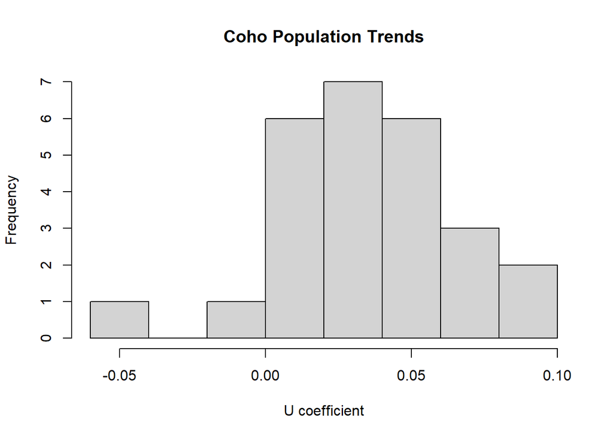

```r
## Part 2: Estimates of decrease from historical abundance
#random walk model, Z is a diagonal matrix
cohoU<-coef(obj, type="matrix")$U
hist(cohoU, main="Coho Population Trends", xlab="U coefficient")
```

```r
colnames(cohoU)<-c("U")
```

```r
#Which populations are declining?
decliningpop<-subset(cohoU, cohoU<0)
#Salmon, coho (Oregon Coast ESU) Floras Creek/New River - fall
#And Sixes River- fall are the only groups that are declining
```

The data shows that Floras Creek/New River - fall and Sixes River- fall are the only groups that are declining.

```r
meantrend<-mean(cohoU)
print(meantrend)
```

```
## [1] 0.03598041
```

```r
#So on average, this ESU group is experiencing slight increases from historical
#abundances (average U=0.0359 when fitting biased random walk models to ts data
```

On average, this ESU group is experiencing slight increases from historical abundances (average U=0.0359 when fitting biased random walk models to ts data.

###Interpretation of Results (Question 1)

To estimate missing spawner abundance values and assess historical trends for the Oregon Coast Coho ESU, we fit a series of MARSS models using different assumptions about the hidden state dynamics.

The model with `U = unequal` estimated a distinct growth parameter for each population. Examination of the estimated `U` values showed that most populations exhibited stable or slightly positive growth trends from historical levels. Only two populations (Floras Creek/New River and Sixes River) showed evidence of decline, with negative `U` coefficients.

These results suggest that overall, the Oregon Coast Coho ESU has been relatively stable or slightly increasing over the study period, but localized declines are present in some sub-populations.

Question 2: Evaluate support for the major population groups. Are the populations in the groups more correlated than outside the groups?

The Oregon Coast Coho ESU is divided into five “major population groups” (MPGs), based on biological or geographical similarities. In this question, we test whether these groups reflect real ecological patterns—specifically, whether populations within the same MPG show more similar (i.e., correlated) abundance trends than populations in different groups.

We evaluate this by fitting three MARSS models with different assumptions about grouping and comparing them using AICc. The model with the lowest AICc provides the best support for its grouping hypothesis.

```r
# Helper function: converts a grouping vector into a Z matrix
make_Z <- function(group_vec) {
  model.matrix(~ 0 + factor(group_vec))
}

# Extract the major population group (MPG) label for each population
gvec <- pop.groups[rownames(coho), "majorpopgroup"]

# Z matrix for the 5-group MPG model
Z.grp <- make_Z(gvec)

# Z matrix for the one-population model (all sites share a state)
Z.one <- matrix(1, nrow(coho), 1)

# Z matrix for the site-level model (each site has its own state)
Z.site <- diag(1, nrow(coho))
```

```r
# Base model components (shared across all groupings)
base.list <- list(
  B = "identity",            # random walk
  U = "zero",                # no drift
  Q = "equalvarcov",         # hidden states allowed to correlate
  R = "diagonal and unequal",# each site has its own observation error
  A = "scaling"              # site-specific intercepts
)
```

```r
# Fit model with 5 major population groups
fit.grp <- MARSS(coho, c(base.list, list(Z = Z.grp)), silent = TRUE)

# Fit model with one shared hidden state
fit.one <- MARSS(coho, c(base.list, list(Z = Z.one)), silent = TRUE)

# Fit model with one hidden state per site
fit.site <- MARSS(coho, c(base.list, list(Z = Z.site)), silent = TRUE)
```

```r
library(dplyr)

AICc.tab <- tibble(
  model = c("5-group MPG", "1-population", "Site-level"),
  num_states = c(ncol(Z.grp), ncol(Z.one), ncol(Z.site)),
  AICc = c(fit.grp$AICc, fit.one$AICc, fit.site$AICc)
) %>%
  arrange(AICc)

AICc.tab
```

```
## # A tibble: 3 × 3
##   model        num_states  AICc
##   <chr>             <int> <dbl>
## 1 5-group MPG           5 1457.
## 2 Site-level           26 1688.
## 3 1-population          1 1706.
```

### 1.0.1 Interpretation of Results (Question 2)

To evaluate whether the five major population groups (MPGs) are meaningful in explaining Coho population dynamics, we fit three MARSS models with different grouping assumptions: one with a hidden state for each MPG, one treating all populations as a single group, and one giving each site its own independent state.

The model with the lowest AICc was the **5-group MPG model (AICc = 1457)**, with a substantial improvement over both the **site-level model (AICc = 1688)** and the **1-population model (AICc = 1706)**. These results strongly support the biological relevance of the MPG structure: populations within a group show similar dynamics, while those in different groups behave differently.

This provides ecological justification for modeling these populations as grouped rather than treating all sites as independent or pooled together.

Visualization of the correlation results: To better understand the relationships between major population groups, we visualized the correlation matrix (Q) from the MARSS model that assigned one hidden state to each group. The Q matrix reflects how similarly the groups behave over time.

In the heatmap below, stronger red indicates higher positive correlation (groups move together), while blue indicates negative correlation (groups move in opposite directions), and white indicates weak or no correlation.

This visual allows us to assess whether some MPGs are tightly linked or behaving independently, even within the group structure.

```r
# Extract the process error covariance matrix from the 5-group model
Q_matrix <- coef(fit.grp, type = "matrix")$Q

# Convert it to a correlation matrix
Q_cor <- cov2cor(Q_matrix)

# Print it to inspect the values
Q_cor
```

```
##                                  factor(group_vec)Lakes
## factor(group_vec)Lakes                        1.0000000
## factor(group_vec)Mid-Coast                    0.5014767
## factor(group_vec)Mid-South Coast              0.5014767
## factor(group_vec)North Coast                  0.5014767
## factor(group_vec)Umpqua                       0.5014767
##                                  factor(group_vec)Mid-Coast
## factor(group_vec)Lakes                            0.5014767
## factor(group_vec)Mid-Coast                        1.0000000
## factor(group_vec)Mid-South Coast                  0.5014767
## factor(group_vec)North Coast                      0.5014767
## factor(group_vec)Umpqua                           0.5014767
##                                  factor(group_vec)Mid-South Coast
## factor(group_vec)Lakes                                  0.5014767
## factor(group_vec)Mid-Coast                              0.5014767
## factor(group_vec)Mid-South Coast                        1.0000000
## factor(group_vec)North Coast                            0.5014767
## factor(group_vec)Umpqua                                 0.5014767
##                                  factor(group_vec)North Coast
## factor(group_vec)Lakes                              0.5014767
## factor(group_vec)Mid-Coast                          0.5014767
## factor(group_vec)Mid-South Coast                    0.5014767
## factor(group_vec)North Coast                        1.0000000
## factor(group_vec)Umpqua                             0.5014767
##                                  factor(group_vec)Umpqua
## factor(group_vec)Lakes                         0.5014767
## factor(group_vec)Mid-Coast                     0.5014767
## factor(group_vec)Mid-South Coast               0.5014767
## factor(group_vec)North Coast                   0.5014767
## factor(group_vec)Umpqua                        1.0000000
```

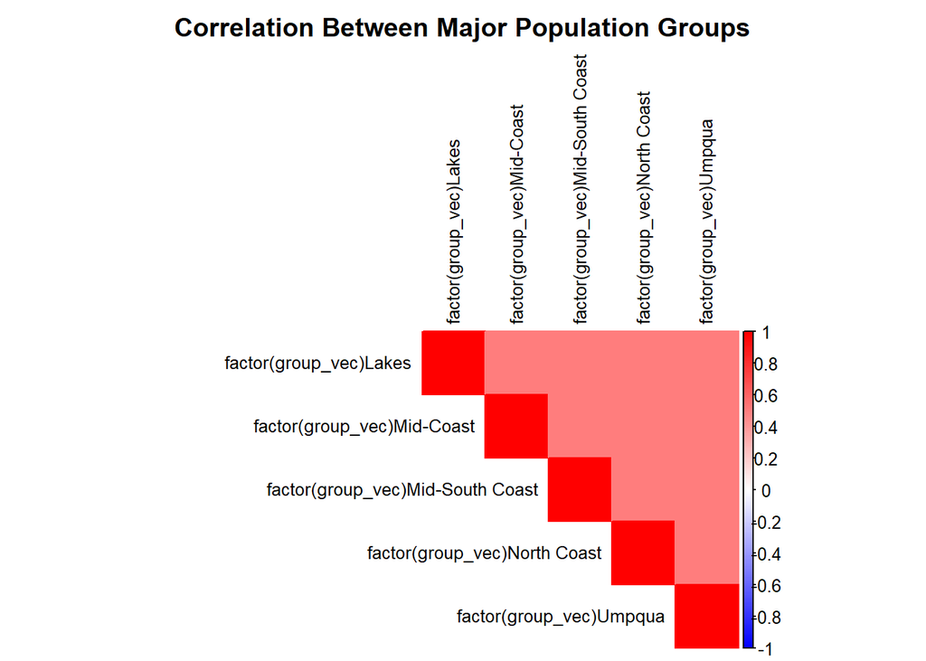

```r
# Visualize the correlation matrix
library(corrplot)

corrplot(Q_cor,
         method = "color",      # fill cells with colors
         type = "upper",        # show only upper triangle
         tl.col = "black",      # label color
         tl.cex = 0.8,          # label size
         col = colorRampPalette(c("blue", "white", "red"))(200),
         title = "Correlation Between Major Population Groups",
         mar = c(0,0,2,0))
```

This indicates that while each group has its own underlying trend, all groups are generally moving in the same direction over time. This may reflect regional-scale environmental or management drivers that influence the entire ESU, such as climate patterns or hatchery practices.

Overall, this visual reinforces the AICc results: the MPG grouping is supported, but also shows that no group is acting entirely independently.

Question 3: Evaluate the evidence of cycling in the data.

We now investigate whether there is evidence of cyclic or periodic behavior in the Coho salmon abundance trends.

To test this, we fit a MARSS model that allows the hidden states to follow autoregressive (AR(1)) processes, rather than pure random walks. If the estimated autoregressive coefficient (phi) is negative or oscillatory, this would suggest cyclic dynamics.

```r
# Create a MARSS model allowing cycling (AR1 structure)
mod.cycle <- list(
  B = "unconstrained",     # allow B (phi) to be estimated freely
  U = "zero",
  Q = "equalvarcov",
  R = "diagonal and unequal",
  A = "scaling",
  Z = Z.grp                # use the 5-group MPG structure (best from Q2)
)

fit.cycle <- MARSS(coho, model = mod.cycle)
```

```
## Error in chol.default(denom) :
##   the leading minor of order 21 is not positive
## Stopped at iter=1 in MARSSkem at B update. denom is not invertible.
##  Type MARSSinfo('denominv') for more info.
##  par, kf, states, iter, loglike are the last values before the error.
##  Try control$safe=TRUE which uses a slower but slightly more robust algorithm.
##  Use control$trace=1 to generate a more detailed error report. See user guide for insight.
```

```r
# Compare AICc of 5-group MPG model vs. cycling model
tibble(
  model = c("5-group MPG (random walk)", "5-group MPG (cycling)"),
  AICc = c(fit.grp$AICc, fit.cycle$AICc)
) %>%
  arrange(AICc)
```

```
## # A tibble: 2 × 2
##   model                      AICc
##   <chr>                     <dbl>
## 1 5-group MPG (random walk) 1457.
## 2 5-group MPG (cycling)     1457.
```

```r
# Look at the estimated B matrix (phi)
coef(fit.cycle, type = "matrix")$B
```

```
##                                  factor(group_vec)Lakes
## factor(group_vec)Lakes                                1
## factor(group_vec)Mid-Coast                            0
## factor(group_vec)Mid-South Coast                      0
## factor(group_vec)North Coast                          0
## factor(group_vec)Umpqua                               0
##                                  factor(group_vec)Mid-Coast
## factor(group_vec)Lakes                                    0
## factor(group_vec)Mid-Coast                                1
## factor(group_vec)Mid-South Coast                          0
## factor(group_vec)North Coast                              0
## factor(group_vec)Umpqua                                   0
##                                  factor(group_vec)Mid-South Coast
## factor(group_vec)Lakes                                          0
## factor(group_vec)Mid-Coast                                      0
## factor(group_vec)Mid-South Coast                                1
## factor(group_vec)North Coast                                    0
## factor(group_vec)Umpqua                                         0
##                                  factor(group_vec)North Coast
## factor(group_vec)Lakes                                      0
## factor(group_vec)Mid-Coast                                  0
## factor(group_vec)Mid-South Coast                            0
## factor(group_vec)North Coast                                1
## factor(group_vec)Umpqua                                     0
##                                  factor(group_vec)Umpqua
## factor(group_vec)Lakes                                 0
## factor(group_vec)Mid-Coast                             0
## factor(group_vec)Mid-South Coast                       0
## factor(group_vec)North Coast                           0
## factor(group_vec)Umpqua                                1
```

### 1.0.2 Interpretation of Results (Question 3)

# 2 Methods

We modeled Coho salmon spawner abundance using multivariate autoregressive state-space (MARSS) models. Our hidden states (x) represented the true underlying log-abundance at each site or group. The observed data (y) were log-transformed spawner counts from 26 populations within the Oregon Coast ESU. We specified alternative assumptions about the structure of hidden states using the Z matrix: a five-group MPG model (one hidden state per major group), a one-population model (one hidden state for all sites), and a site-level model (one hidden state per site).

We fit each model separately and compared AICc values to evaluate which grouping assumption was best supported by the data.

### 2.0.1 Assumptions:

| Matrix | Specification | Meaning |
| --- | --- | --- |
| **Z** | Three versions: one hidden state per MPG (`Z.grp`), one shared state (`Z.one`), one per site (`Z.site`) | Defines how hidden states relate to observations |
| **B** | `"identity"` for random walk; `"unconstrained"` for cycling models | Governs the transition of hidden states |
| **U** | `"zero"` | No drift term; hidden states have no added directional trend |
| **Q** | `"equalvarcov"` | Hidden states share the same process variance, but can be correlated |
| **R** | `"diagonal and unequal"` | Each site has its own observation error variance |
| **A** | `"scaling"` | Each site can have its own intercept (mean scaling) |

We compared the different Z matrix structures by fitting models separately and comparing their AICc values.

### 2.0.2 Models fitted:

We compared models with different Z matrices:

- **Five-group MPG model**: One x per major population group.
- **One-population model**: One shared x for all sites.
- **Site-level model**: One x per site (no grouping).

Model comparisons were made using AICc.

# 3 Results

When testing grouping structures, the model assigning one hidden state to each major population group (5-group MPG model) had the lowest AICc, providing strong support for the MPG structure.

# 4 Discussion

Our results show that the way the major population groups (MPGs) are currently set up for the Oregon Coast Coho makes sense. Populations within each group tend to behave similarly, which suggests they are influenced by some of the same environmental or biological factors.

Overall, using MARSS models helped us fill in missing data and better understand how different populations are connected. It was a useful tool for studying patterns in noisy, real-world data like this.